# Dimensionality Reduction

## 10/19/2021

print view

```python
%%html
<script src="http://bits.csb.pitt.edu/asker.js/lib/asker.js"></script>
<script>

require(['https://cdnjs.cloudflare.com/ajax/libs/Chart.js/2.2.2/Chart.js'], function(Ch){
 Chart = Ch;
});

$('head').append('<link rel="stylesheet" href="http://bits.csb.pitt.edu/asker.js/themes/asker.default.css" />');


//the callback is provided a canvas object and data
var chartmaker = function(canvas, labels, data) {
  var ctx = $(canvas).get(0).getContext("2d");
     var dataset = {labels: labels,
    datasets:[{
     data: data,
     backgroundColor: "rgba(150,64,150,0.5)",
         fillColor: "rgba(150,64,150,0.8)",
  }]};
  var myBarChart = new Chart(ctx,{type:'bar',data:dataset,options:{legend: {display:false},
        scales: {
            yAxes: [{
                ticks: {
                    min: 0,
                }
            }]}}});
};

$(".jp-InputArea .o:contains(html)").closest('.jp-InputArea').hide();


</script>
```

# Recall

```
(4381, 23)
```

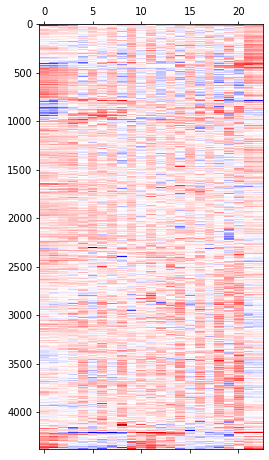

```python
from matplotlib.pylab import cm
import numpy as np
import scipy.cluster.hierarchy as hclust
import matplotlib.pyplot as plt
data = np.genfromtxt('Spellman.csv',skip_header=1,delimiter=',')[:,1:]
Z = hclust.linkage(data,method='complete')
leaves = hclust.leaves_list(Z)
ordered = data[leaves]
print(data.shape)
plt.matshow(ordered,aspect=0.01,cmap=cm.seismic);
```

```python
%%html
<div id="howdim" style="width: 500px"></div>
<script>
$('head').append('<link rel="stylesheet" href="http://bits.csb.pitt.edu/asker.js/themes/asker.default.css" />');

    var divid = '#howdim';
	jQuery(divid).asker({
	    id: divid,
	    question: "What is the dimensionality of this data?",
		answers: ['1','2','23','4381','None of the above'],
        server: "http://bits.csb.pitt.edu/asker.js/example/asker.cgi",
		charter: chartmaker})

$(".jp-InputArea .o:contains(html)").closest('.jp-InputArea').hide();


</script>
```

# Dimenionality Reduction

$$f(\mathbb{R}^N) \rightarrow \mathbb{R}^M, M < N$$

Usually used for visualization so reduce to 2 or 3 dimensions.

Goal is for distances in $\mathbb{R}^M$ to be representative of distances in $\mathbb{R}^N$

# PCA

Recall: principal component analysis finds an orthogonal basis that best represents the variance in the data.

[figure not shown]

```python
from sklearn.decomposition import PCA
```

```python
model = PCA(n_components=2) #specify number of components
pcaresult = model.fit_transform(data)
```

```python
model.explained_variance_ratio_
```

```
array([0.29005293, 0.15421722])
```

```python
pcaresult
```

```
array([[ 0.53743596,  0.04236279],
       [-0.52117275,  0.23262809],
       [-0.92718811, -0.02687601],
       ...,
       [ 2.22481438, -0.63181588],
       [-1.90513202,  0.62147878],
       [-1.52881942,  1.02728412]])
```

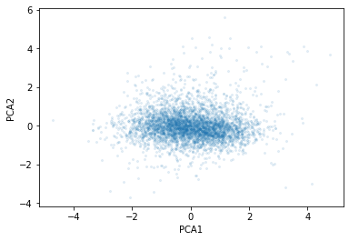

```python
plt.scatter(pcaresult[:,0],pcaresult[:,1],s=4,alpha=.1)
plt.xlabel('PCA1'); plt.ylabel('PCA2');
```

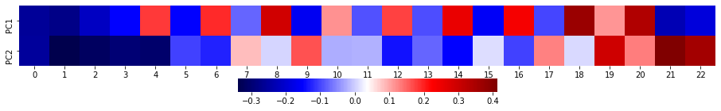

```python
import seaborn as sns
plt.figure(figsize=(16,2))
sns.heatmap(model.components_,cmap=cm.seismic,yticklabels=['PC1','PC2'],
            square=True, cbar_kws={"orientation": "horizontal"});
```

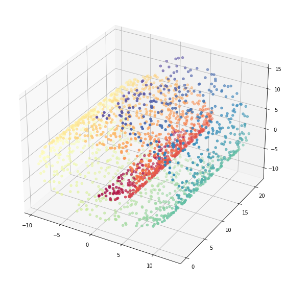

```python
import sklearn.datasets
X,color=sklearn.datasets.make_swiss_roll(n_samples=2000)
fig = plt.figure(figsize=(10,10))
ax = plt.axes(projection='3d')
ax.scatter(X[:, 0], X[:, 1], X[:, 2], c=color, cmap=plt.cm.Spectral);
```

```python
%%html
<div id="howpca" style="width: 500px"></div>
<script>
$('head').append('<link rel="stylesheet" href="http://bits.csb.pitt.edu/asker.js/themes/asker.default.css" />');

    var divid = '#howpca';
	jQuery(divid).asker({
	    id: divid,
	    question: "What will the PCA projection to 2D of this data look like?",
		answers: ['Gaussian','Gradient','Spiral','Messy','Square'],
        server: "http://bits.csb.pitt.edu/asker.js/example/asker.cgi",
		charter: chartmaker})

$(".jp-InputArea .o:contains(html)").closest('.jp-InputArea').hide();


</script>
```

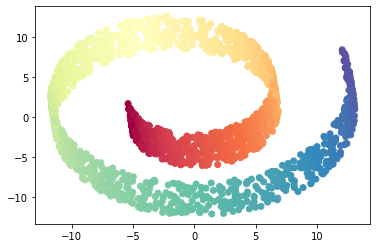

```python
model = PCA(n_components=2) #specify number of components
result = model.fit_transform(X)
plt.scatter(result[:,0],result[:,1],c=color,cmap=plt.cm.Spectral);
```

Is this a better projection?

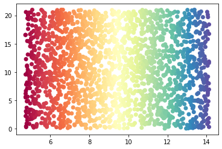

```python
plt.scatter(color,X[:,1],c=color,cmap=plt.cm.Spectral);
```

# UMAP: Uniform Manifold Approximation & Projection

https://umap-learn.readthedocs.io/en/latest/index.html

Idea: Prioritize respecting **local** distances in embedding space.

[figure not shown]

# UMAP: Uniform Manifold Approximation & Projection

UMAP constructs a $k$-nearest neighbors graph of the data. It uses an approximate **stochastic** algorithm to do this quickly.

[figure not shown]

# UMAP: Uniform Manifold Approximation & Projection

Optimizes position of data points in low dimensional space to balance attraction of locally adjacent points and repulsion of unconnected, distance points.

$$\mathrm{minimize}\sum_{e\in E} \color{blue}{ w_h(e) \log\left(\frac{w_h(e)}{w_l(e)}\right)} + \color{darkred}{(1 - w_h(e)) \log\left(\frac{1 - w_h(e)}{1 - w_l(e)}\right)}$$

$w_h(e)$ weight of edge in **high** dimensional space (larger weight = smaller distance)

$w_l(e)$ weight of edge in **low** dimensional space (larger weight = smaller distance)

This optimization is done using **stochastic gradient descent** starting at a deterministically constructed initial embedding.

# UMAP: Uniform Manifold Approximation & Projection

The `umap` package is installed with `pip3 umap-learn`

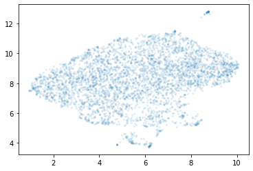

```python
import umap
model = umap.UMAP()
result = model.fit_transform(data)
plt.scatter(result[:,0],result[:,1],s=4,alpha=.1);
```

## PCA

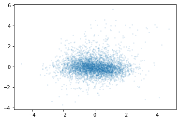

```python
plt.scatter(pcaresult[:,0],pcaresult[:,1],s=4,alpha=.1);
```

# UMAP Parameters

- `n_neighbors` (15): Number of nearest neighbors to consider. Increase to respect global structure more.
- `min_dist` (0.1): Minimum distance between points in reduced space. Decrease to have more tightly clustered points.
- `metric` ("euclidean"): How distance is computed. Can provide user-supplied functions in addition to standard metrics

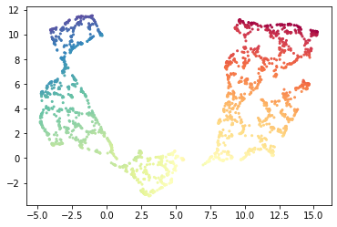

```python
model = umap.UMAP(); result = model.fit_transform(X)
plt.scatter(result[:,0],result[:,1],s=4,c=color,cmap=plt.cm.Spectral);
```

### n_neighbors

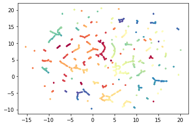

```python
model = umap.UMAP(n_neighbors=3); result = model.fit_transform(X)
plt.scatter(result[:,0],result[:,1],s=4,c=color,cmap=plt.cm.Spectral);
```

## n_neighbors

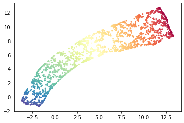

```python
model = umap.UMAP(n_neighbors=100); result = model.fit_transform(X)
plt.scatter(result[:,0],result[:,1],s=4,c=color,cmap=plt.cm.Spectral);
```

## min_dist

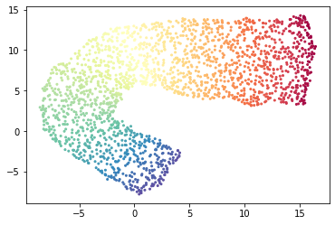

```python
model = umap.UMAP(n_neighbors=100,min_dist=1); result = model.fit_transform(X)
plt.scatter(result[:,0],result[:,1],s=4,c=color,cmap=plt.cm.Spectral);
```

## metric

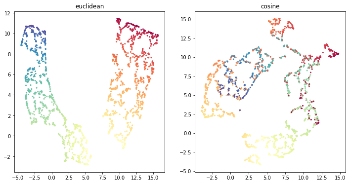

```python
fig,axes = plt.subplots(ncols=2,figsize=(12,6))
model = umap.UMAP(metric='euclidean')
result = model.fit_transform(X)
axes[0].scatter(result[:,0],result[:,1],s=4,c=color,cmap=plt.cm.Spectral); axes[0].set_title('euclidean')
model = umap.UMAP(metric='cosine')
result = model.fit_transform(X)
axes[1].scatter(result[:,0],result[:,1],s=4,c=color,cmap=plt.cm.Spectral); axes[1].set_title('cosine');
```

# UMAP vs. t-SNE

t-SNE (t-distributed stochastic neighbor embedding) is an older method that also uses a notion of preserving local distances

- doesn't use nearest neighbor graph (slower)
- different cost function for optimizing embedding
- more sensitive to parameters
- default to stochastic initialization of optimization

# Project

Download the below heavily downsampled RNASeq data and visualize it in 2D both with PCA and UMAP.

Color the points by the labels.

```python
!wget  http://mscbio2025.net/files/mouse_data/X.csv.gz
!wget  http://mscbio2025.net/files/mouse_data/obs.csv
```

```
--2021-10-18 21:07:42--  http://mscbio2025.net/files/mouse_data/X.csv.gz
Resolving mscbio2025.net (mscbio2025.net)... 136.142.4.139
Connecting to mscbio2025.net (mscbio2025.net)|136.142.4.139|:80... connected.
HTTP request sent, awaiting response... 200 OK
Length: 5447648 (5.2M) [application/x-gzip]
Saving to: ‘X.csv.gz’

X.csv.gz            100%[===================>]   5.19M  20.9MB/s    in 0.2s

2021-10-18 21:07:42 (20.9 MB/s) - ‘X.csv.gz’ saved [5447648/5447648]

--2021-10-18 21:07:43--  http://mscbio2025.net/files/mouse_data/obs.csv
Resolving mscbio2025.net (mscbio2025.net)... 136.142.4.139
Connecting to mscbio2025.net (mscbio2025.net)|136.142.4.139|:80... connected.
HTTP request sent, awaiting response... 200 OK
Length: 101150 (99K) [text/csv]
Saving to: ‘obs.csv’

obs.csv             100%[===================>]  98.78K  --.-KB/s    in 0.08s

2021-10-18 21:07:43 (1.23 MB/s) - ‘obs.csv’ saved [101150/101150]
```

```python
data = np.genfromtxt('X.csv.gz',delimiter=',')
labels = np.genfromtxt('obs.csv',delimiter=',',dtype=str,skip_header=1)[:,1]
```

```python
#convert labels (strings) to numbers so they can be used as colors in matplotlib
from sklearn import preprocessing
colors = preprocessing.LabelEncoder().fit_transform(labels)
```

```python
data.shape
```

```
(1196, 4286)
```

```python
labels.shape
```

```
(1196,)
```

```python
#can use umap's plotting function and provide labels as strings
import umap.plot
```